# Bioinfo Projekt

Ilya

5/1/2021

```r
load("../2021-topic-01-team-03/dataset/prism_datasets.rda")
load("../2021-topic-01-team-03/dataset/cellline_datasets.rda")
```

#Guidelines

prism: effect of the treatment (columns) on cell growth of cell lines (rows).For example, BRD-A00077618-236-07-6::0.0024414::HTS002 indicates treatment with the drug BRD-A00077618-236-07-6, with a dose of 2.4 nM, in assay HTS002. Values represent log fold changes with respect to a control DMSO experiment.

prism.treat:information about the treatment (row) and the drug used

prism.cl: cell lines’ info

prism.exp: gene TPM (transcripts per million) values. Indicate over/underexpression. Rows = cell lines, columns = genes

prism.cnv: gene copy number (CN) values. In absolute terms, CN = 2, since there are two alleles per genes. In cancer, genes might be amplified CN > 2 or deleted CN < 2

prism.snv: observed mutations in a sample. The isDeleterious flag specifies if mutation has a functional effect or not.

prism.achilles: gene KO scores, a measure of how essential/important is a particular gene for the cell survival

IDEA: use same indications as in PRISM paper to start filtering for relevant genes, cell lines?

#Cleaning

##Selecting brain cancer specific cell lines in all data sets

```r
brain_cancer_cl=subset.data.frame(prism.cl, disease ==  "Brain Cancer") #identify the brain cancer cell lines' names

names=brain_cancer_cl[,1] #saving the names as names

#select wanted cell lines from all datasets
brain_cancer=prism[names,]
brain_cancer_achilles=prism.achilles[names,]
brain_cancer_cnv=prism.cnv[names,]
brain_cancer_exp=prism.exp[names,]
#brain_cancer_snv=prism.snv[names,] #does not make sense no cell line info, other type of filtering required
#brain_cancer_treat=prism.treat[names,] #does not make sense no cell line info, other type of filtering required
```

##NA removal

```r
#brain_cancer_achilles=na.omit(brain_cancer_achilles) #remove the entire cell lines from everywhere without KO scores?
```

##NA for mean substituition

```r
for(i in 1:ncol(brain_cancer)){
  brain_cancer[is.na(brain_cancer[,i]), i] <- mean(brain_cancer[,i], na.rm = TRUE)
}

brain_cancer=brain_cancer[ , colSums(is.na(brain_cancer)) == 0]
```

##Deviding drugs in doses groups

```r
dd1=grep("0.00061034", colnames(brain_cancer))
dd2=grep("0.0024414", colnames(brain_cancer))
dd3=grep("0.00976562", colnames(brain_cancer))
dd4=grep("0.0390625", colnames(brain_cancer))
dd5=grep("0.15625", colnames(brain_cancer))
dd6=grep("0.625", colnames(brain_cancer))
dd7=grep("10:", colnames(brain_cancer))
dd8=grep("2.5:", colnames(brain_cancer))
#positions of the respective doses in the dataframe
doses=c(dd1,dd2,dd3,dd4,dd5,dd6,dd7,dd8)

d1=brain_cancer[,dd1]
d2=brain_cancer[,dd2]
d3=brain_cancer[,dd3]
d4=brain_cancer[,dd4]
d5=brain_cancer[,dd5]
d6=brain_cancer[,dd6]
d7=brain_cancer[,dd7]
d8=brain_cancer[,dd8]
#these are the standard doses summed up into seperate dataframes
sum(length(d1), length(d2), length(d3), length(d4),length(d5), length(d6),length(d7),length(d8)) #ups something missing
```

```
## [1] 10298
```

```r
deviation=brain_cancer[,-doses] #lets see what we missed-> these are the doses that are not exact and have some kind of a deviation

#rest of the doeses are all different. What do we do with them?

#lets keep from "deviation" only the ones that have a deviation less than "10%" from original

#to do: make a distribution test for a non normal distribution to justify the 10%

questionable_drugs=prism.treat[colnames(deviation),]#we dont know if we can use these drugs, may be their doses deviate too far from the standard

#filtering the doses that deviate less than 10%

keep_d1=which (0.00061034-0.1*0.00061034 < questionable_drugs[,2] & 0.00061034+0.1*0.00061034 >questionable_drugs[,2]) #apply the 10% gap and find which genes are that qualify for it
d1_extra=brain_cancer[,rownames(questionable_drugs[keep_d1,])] #create a dataframe with these genes
d1=cbind(d1,d1_extra) #merge the obtained dataframe with the standard dose one

keep_d2=which (0.0024414-0.1*0.0024414 < questionable_drugs[,2] & 0.0024414+0.1*0.0024414 >questionable_drugs[,2])
d2_extra=brain_cancer[,rownames(questionable_drugs[keep_d2,])]
d2=cbind(d2,d2_extra)

keep_d3=which (0.00976562-0.1*0.00976562 < questionable_drugs[,2] & 0.00976562+0.1*0.00976562 >questionable_drugs[,2])
d3_extra=brain_cancer[,rownames(questionable_drugs[keep_d3,])]
d3=cbind(d3,d3_extra)

keep_d4=which (0.0390625-0.1*0.0390625 < questionable_drugs[,2] & 0.0390625+0.1*0.0390625 >questionable_drugs[,2])
d4_extra=brain_cancer[,rownames(questionable_drugs[keep_d4,])]
d4=cbind(d4,d4_extra)

keep_d5=which (0.15625-0.1*0.15625 < questionable_drugs[,2] & 0.15625+0.1*0.15625 >questionable_drugs[,2])
d5_extra=brain_cancer[,rownames(questionable_drugs[keep_d5,])]
d5=cbind(d5,d5_extra)

keep_d6=which (0.625-0.1*0.625 < questionable_drugs[,2] & 0.625+0.1*0.625 >questionable_drugs[,2])
d6_extra=brain_cancer[,rownames(questionable_drugs[keep_d6,])]
d6=cbind(d6,d6_extra)

keep_d7=which (10-0.1*10 < questionable_drugs[,2] & 10+0.1*10 >questionable_drugs[,2])
d7_extra=brain_cancer[,rownames(questionable_drugs[keep_d7,])]
d7=cbind(d7,d7_extra)

keep_d8=which (2.5-0.1*2.5 < questionable_drugs[,2] & 2.5+0.1*2.5 >questionable_drugs[,2])
d8_extra=brain_cancer[,rownames(questionable_drugs[keep_d8,])]
d8=cbind(d8,d8_extra)


#look at the drugs we did not keep
keep=c(keep_d1, keep_d2, keep_d3, keep_d4,keep_d5,keep_d6,keep_d7,keep_d8)
View(deviation[,-keep])

mean(apply(deviation[,-keep],2,mean))#curioisty
```

```
## [1] -0.7103844
```

##Selecting relevant drugs

```r
no_keep_drugs=colnames(deviation[,-keep])#vector with NAMES of drugs we dont want
no_keep_drugs=unique (grep(paste(no_keep_drugs,collapse="|"), colnames(brain_cancer)))#vector of POSITIONS of drugs we dont want in dataframe brain_cancer
brain_cancer=brain_cancer[,-no_keep_drugs]#removing the drugs we dont want

max=apply(brain_cancer,2,max)
min=apply(brain_cancer,2,min)
mean=apply(brain_cancer,2,mean)
median=apply(brain_cancer,2,median)
#add quantiles to the dataframe?

drug_summary=data.frame(max, min, mean, median)
sum(is.na(drug_summary$mean))
```

```
## [1] 0
```

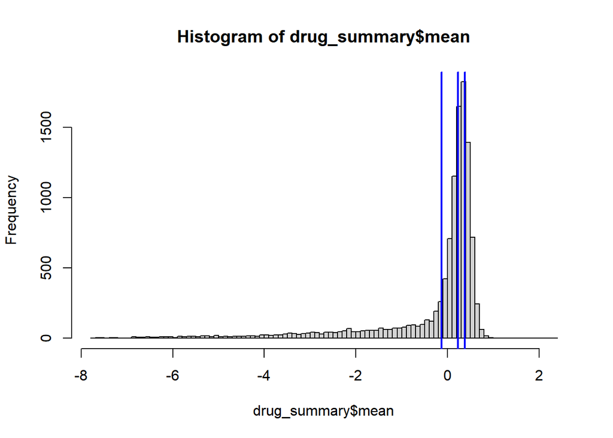

```r
hist(drug_summary$mean, breaks = 100,)
abline(v = quantile(drug_summary$mean, c(0.25,0.5,0.75)), col = "blue", lwd = 2)
```

```r
#what would be the type of this distribution? Poisson? Negative binominal?

median(drug_summary$mean) # 0.3 criteria from PRISM paper makes sense since it covers more than a half of the drugs
```

```
## [1] 0.2259365
```

```r
mean(drug_summary$mean)
```

```
## [1] -0.2686799
```

##Apllying the dosis separation of dataset brain_cancer on prism.treat

```r
brain_canancer_treat=prism.treat[colnames(brain_cancer),] #selecting only the drugs ve previously filtered out from brain_cancer

dt1=brain_canancer_treat[colnames(d1),]
dt2=brain_canancer_treat[colnames(d2),]
dt3=brain_canancer_treat[colnames(d3),]
dt4=brain_canancer_treat[colnames(d4),]
dt5=brain_canancer_treat[colnames(d5),]
dt6=brain_canancer_treat[colnames(d6),]
dt7=brain_canancer_treat[colnames(d7),]
dt8=brain_canancer_treat[colnames(d8),]

#not sure this sorting makes sense now for the brain_cancer_treat, but now we have it in case we need it in the future

summary(brain_canancer_treat)#can be useful to identify trends or come up with some new ideas for filtering, interesting columns can be looked at separetely, for example:
```

```
##                    broad_id          dose            screen_id
##  BRD-A00077618-236-07-6:    8   Min.   : 0.000558   HTS002:11043
##  BRD-A00758722-001-04-9:    8   1st Qu.: 0.009097   MTS005:    0
##  BRD-A01643550-001-04-9:    8   Median : 0.148331   MTS006:    0
##  BRD-A02180903-001-04-5:    8   Mean   : 1.668294   MTS010:    0
##  BRD-A03216249-003-24-3:    8   3rd Qu.: 2.345740
##  BRD-A03506276-001-01-5:    8   Max.   :10.760400
##  (Other)               :10995
##  compound_plate                  name
##  PREP014: 320   doxycycline        :   16
##  PREP016: 320   U-0126             :   16
##  PREP017: 320   1-azakenpaullone   :    8
##  PREP020: 320   1-naphthyl-PP1     :    8
##  PREP021: 320   1-phenylbiguanide  :    8
##  PREP022: 320   10-deacetylbaccatin:    8
##  (Other):9123   (Other)            :10979
##                               moa            target
##  EGFR inhibitor                 : 239   MTOR    : 120
##  glucocorticoid receptor agonist: 192   EGFR    : 104
##  HDAC inhibitor                 : 188   NR3C1   :  80
##  topoisomerase inhibitor        : 152   TOP2A   :  72
##  MEK inhibitor                  : 148   HSP90AA1:  64
##  (Other)                        :9570   (Other) :8361
##  NA's                           : 554   NA's    :2242
##                  disease.area                                 indication
##  oncology              : 584   breast cancer                       : 104
##  infectious disease    : 536   corticosteroid-responsive dermatoses:  80
##  neurology/psychiatry  : 400   prostate cancer                     :  80
##  hematologic malignancy: 319   contraceptive                       :  72
##  cardiology            : 264   hypertension                        :  72
##  (Other)               :1840   (Other)                             :3535
##  NA's                  :7100   NA's                                :7100
##                                                                                                                                                                                                                                                                                                          …
##  C[C@@H]1[C@H]2[C@H](O)[C@H]3[C@H](N(C)C)C(=O)C(C(N)=O)C(=O)[C@@]3(O)C(=O)C2C(=O)c2c(O)cccc12, C[C@@H]1[C@H]2[C@H](O)[C@H]3[C@H](N(C)C)C(=O)C(C(N)=O)C(=O)[C@@]3(O)C(=O)C2C(=O)c2c(O)cccc12, C[C@@H]1[C@H]2[C@H](O)[C@H]3[C@H](N(C)C)C(=O)C(C(N)=O)C(=O)[C@@]3(O)C(=O)C2C(=O)c2c(O)cccc12, C[C@@H]1[C@H]2…
##  N\\C(Sc1ccccc1N)=C(C#N)/C(C#N)=C(/N)Sc1ccccc1N, N\\C(Sc1ccccc1N)=C(C#N)/C(C#N)=C(\\N)Sc1ccccc1N, N\\C(Sc1ccccc1N)=C(C#N)/C(C#N)=C(/N)Sc1ccccc1N                                                                                                                                                         …
##  , NCC=C.ClCC1CO1                                                                                                                                                                                                                                                                                        …
##  [2H]C([2H])([2H])C(O)(CCO[C@@H](C)[C@H]1CC[C@@H]2[C@]1(C)CCC\\C2=C/C=C1/C[C@@H](O)C[C@H](O)C1=C)C([2H])([2H])[2H]                                                                                                                                                                                       …
##  [I+]1c2ccccc2-c2ccccc12                                                                                                                                                                                                                                                                                 …
##  [Na].OC(=O)C(Cl)Cl, [Na].OC(=O)C(Cl)Cl                                                                                                                                                                                                                                                                  …
##  (Other)                                                                                                                                                                                                                                                                                                 …
##              phase
##  Launched       :4295
##  Preclinical    :3216
##  Phase 2        :1367
##  Phase 1        : 983
##  Phase 3        : 774
##  Phase 1/Phase 2: 184
##  (Other)        : 224
```

```r
summary(brain_canancer_treat$disease.area)
```

[output not shown]

[output cut: 145 more lines]

```
##                                                                                                                         8
##                                             rheumatology, otolaryngology, gastroenterology, neurology/psychiatry, allergy
##                                                                                                                         8
##                                                                                                                transplant
##                                                                                                                        24
##                                                                                                     transplant, pulmonary
##                                                                                                                         8
##                                                                                                  transplant, rheumatology
##                                                                                                                         8
##                                                                                     transplant, rheumatology, dermatology
##                                                                                                                         0
##                                                                                                                   urology
##                                                                                                                        24
##                                                                                                                      NA's
##                                                                                                                      7100
```

```r
##Dividing cell lines into subgroups
```

```r
medulloblastoma=brain_cancer_cl$DepMap_ID[grep("Medulloblastoma", brain_cancer_cl$disease_subtype)]#we obtain the names of the cell lines that are classified as medulloblastoma

glioblastoma=brain_cancer_cl$DepMap_ID[grep("Glioblastoma", brain_cancer_cl$disease_subtype)]

glioma=brain_cancer_cl$DepMap_ID[grep("Glioma", brain_cancer_cl$disease_subtype)]

astrocytoma=brain_cancer_cl$DepMap_ID[grep("Astrocytoma", brain_cancer_cl$disease_subtype)]

disease_subtypes=c(medulloblastoma,glioblastoma,glioma,astrocytoma)
length(disease_subtypes)#making sure we didnt forget anything
```

```
## [1] 34
```

##Clustering

[output not shown]

## Analyse the variance of the eigenvalues

[output not shown]

# Compute and plot wss for k = 2 to k = 12

[output not shown]